# F3 changes in Glasgow vowels / r

# Males, take 2 (with baseline control)

```r
if (refit_please) {
  system.time(
    R.m.baseline.mod.no.AR <- bam(f3 ~ stress +
                          avg.f3 +
                       # level 1 smooth terms
                          s(measurement.no) +
                          s(decade, k=4) +
                          s(duration) +
                          s(preceding.front, k=3) +
                       # level 2: by terms
                          s(measurement.no, by=stress) +
                          s(decade, k=4, by=stress) +
                       # level 2: 2d smooths
                          ti(measurement.no, decade, k=c(10,4)) +
                          ti(measurement.no, duration) +
                          ti(measurement.no, preceding.front, k=c(10,3)) +
                       # level 3: 2d smooth by terms
                          ti(measurement.no, decade, k=c(10,4), by=stress) +
                       # random smooths
                          s(measurement.no, foll.broad.f3, bs="fs", m=1, k=4) +
                          s(measurement.no, speaker, bs="fs", m=1, k=4) +
                          s(measurement.no, word, bs="fs", m=1, k=4),
                      dat=R.m)
  )
  # saveRDS(R.m.baseline.mod.no.AR, "models/R.m.baseline.mod.no.AR")

  R.m.baseline.rho <- start_value_rho(R.m.baseline.mod.no.AR)

  system.time(
    R.m.baseline.mod.AR <- bam(f3 ~ stress +
                          avg.f3 +
                       # level 1 smooth terms
                          s(measurement.no) +
                          s(decade, k=4) +
                          s(duration) +
                          s(preceding.front, k=3) +
                       # level 2: by terms
                          s(measurement.no, by=stress) +
                          s(decade, k=4, by=stress) +
                       # level 2: 2d smooths
                          ti(measurement.no, decade, k=c(10,4)) +
                          ti(measurement.no, duration) +
                          ti(measurement.no, preceding.front, k=c(10,3)) +
                       # level 3: 2d smooth by terms
                          ti(measurement.no, decade, k=c(10,4), by=stress) +
                       # random smooths
                          s(measurement.no, foll.broad.f3, bs="fs", m=1, k=4) +
                          s(measurement.no, speaker, bs="fs", m=1, k=4) +
                          s(measurement.no, word, bs="fs", m=1, k=4),
                      dat=R.m, method="ML",
                      AR.start=R.m$start.event, rho=R.m.baseline.rho)
  )
  # saveRDS(R.m.baseline.mod.AR, "models/R.m.baseline.mod.AR")

  summary(R.m.baseline.mod.AR)

  system.time(
    R.m.baseline.mod.AR.min.decade <- bam(f3 ~ stress +
                          avg.f3 +
                       # level 1 smooth terms
                          s(measurement.no) +
                          #s(decade, k=4) +
                          s(duration) +
                          s(preceding.front, k=3) +
                       # level 2: by terms
                          s(measurement.no, by=stress) +
                          #s(decade, k=4, by=stress) +
                       # level 2: 2d smooths
                          #ti(measurement.no, decade, k=c(10,4)) +
                          ti(measurement.no, duration) +
                          ti(measurement.no, preceding.front, k=c(10,3)) +
                       # level 3: 2d smooth by terms
                          #ti(measurement.no, decade, k=c(10,4), by=stress) +
                       # random smooths
                          s(measurement.no, foll.broad.f3, bs="fs", m=1, k=4) +
                          s(measurement.no, speaker, bs="fs", m=1, k=4) +
                          s(measurement.no, word, bs="fs", m=1, k=4),
                      dat=R.m, method="ML",
                      AR.start=R.m$start.event, rho=R.m.baseline.rho)
  )
# saveRDS(R.m.baseline.mod.AR.min.decade, "models/R.m.baseline.mod.AR.min.decade")
}
R.m.baseline.mod.no.AR <- readRDS("models/R.m.baseline.mod.no.AR")
R.m.baseline.mod.AR <- readRDS("models/R.m.baseline.mod.AR")
R.m.baseline.mod.AR.min.decade <- readRDS("models/R.m.baseline.mod.AR.min.decade")
compareML(R.m.baseline.mod.AR, R.m.baseline.mod.AR.min.decade)
```

```
R.m.baseline.mod.AR: f3 ~ stress + avg.f3 + s(measurement.no) + s(decade, k = 4) +
    s(duration) + s(preceding.front, k = 3) + s(measurement.no,
    by = stress) + s(decade, k = 4, by = stress) + ti(measurement.no,
    decade, k = c(10, 4)) + ti(measurement.no, duration) + ti(measurement.no,
    preceding.front, k = c(10, 3)) + ti(measurement.no, decade,
    k = c(10, 4), by = stress) + s(measurement.no, foll.broad.f3,
    bs = "fs", m = 1, k = 4) + s(measurement.no, speaker, bs = "fs",
    m = 1, k = 4) + s(measurement.no, word, bs = "fs", m = 1,
    k = 4)

R.m.baseline.mod.AR.min.decade: f3 ~ stress + avg.f3 + s(measurement.no) + s(duration) + s(preceding.front,
    k = 3) + s(measurement.no, by = stress) + ti(measurement.no,
    duration) + ti(measurement.no, preceding.front, k = c(10,
    3)) + s(measurement.no, foll.broad.f3, bs = "fs", m = 1,
    k = 4) + s(measurement.no, speaker, bs = "fs", m = 1, k = 4) +
    s(measurement.no, word, bs = "fs", m = 1, k = 4)

Chi-square test of ML scores
-----
```

| Model | Score | Edf | Difference | Df | p.value | Sig. |
| --- | --- | --- | --- | --- | --- | --- |
| R.m.baseline.mod.AR.min.decade | 25006.67 | 23 |  |  |  |  |
| R.m.baseline.mod.AR | 25001.75 | 33 | 4.919 | 10.000 | 0.455 |  |

```
AIC difference: -0.04, model R.m.baseline.mod.AR has lower AIC.
```

```
 AIC might not be reliable, as an AR1 model is included (rho1 = 0.848567, rho2 = 0.848567). Only small difference in ML...
```

```
Predictor decade is not a factor.
```

```
Summary:
    * stress : factor; set to the value(s): full.
    * avg.f3 : numeric predictor; set to the value(s): 2405.03714710253.
    * measurement.no : numeric predictor; with 30 values ranging from 0.000000 to 10.000000.
    * decade : numeric predictor; with 4 values ranging from 1970.000000 to 2000.000000.
    * duration : numeric predictor; set to the value(s): 0.122709575.
    * preceding.front : numeric predictor; set to the value(s): 1.
    * foll.broad.f3 : factor; set to the value(s): labial. (Might be canceled as random effect, check below.)
    * speaker : factor; set to the value(s): 00-O-m06. (Might be canceled as random effect, check below.)
    * word : factor; set to the value(s): were. (Might be canceled as random effect, check below.)
    * NOTE : The following random effects columns are canceled: s(measurement.no,foll.broad.f3),s(measurement.no,speaker),s(measurement.no,word)
```

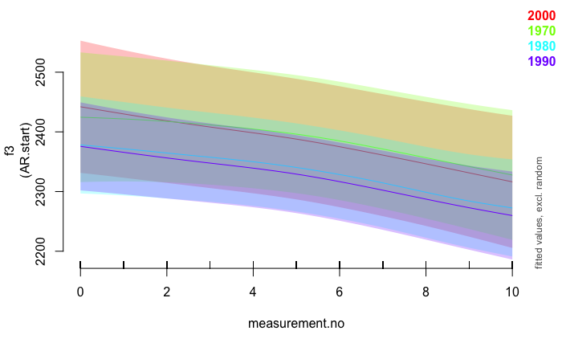

```r
plot_smooth(R.m.baseline.mod.AR, view="measurement.no", plot_all="decade",
            cond=list(stress="full"), rm.ranef=T)
```

```
Predictor decade is not a factor.
```

```
Summary:
    * stress : factor; set to the value(s): schwa.
    * avg.f3 : numeric predictor; set to the value(s): 2405.03714710253.
    * measurement.no : numeric predictor; with 30 values ranging from 0.000000 to 10.000000.
    * decade : numeric predictor; with 4 values ranging from 1970.000000 to 2000.000000.
    * duration : numeric predictor; set to the value(s): 0.122709575.
    * preceding.front : numeric predictor; set to the value(s): 1.
    * foll.broad.f3 : factor; set to the value(s): labial. (Might be canceled as random effect, check below.)
    * speaker : factor; set to the value(s): 00-O-m06. (Might be canceled as random effect, check below.)
    * word : factor; set to the value(s): were. (Might be canceled as random effect, check below.)
    * NOTE : The following random effects columns are canceled: s(measurement.no,foll.broad.f3),s(measurement.no,speaker),s(measurement.no,word)
```

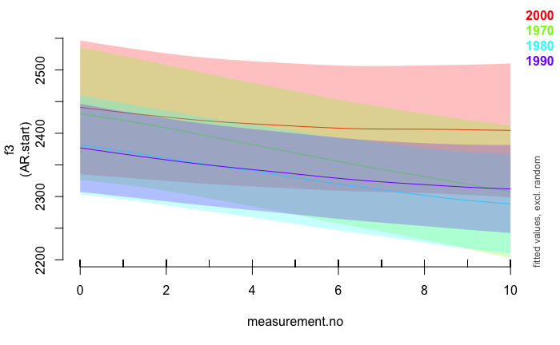

```r
plot_smooth(R.m.baseline.mod.AR, view="measurement.no", plot_all="decade",
            cond=list(stress="schwa"), rm.ranef=T)
```

Further questions:

- overall effect of stress?
- significant change in shape?
- do unstressed / stressed syllables show different changes?
- different shape change?
- different overall change?

```r
if (refit_please) {
  # overall stress?
  system.time(
    R.m.baseline.mod.AR.min.stress <- bam(f3 ~ #stress +
                          avg.f3 +
                       # level 1 smooth terms
                          s(measurement.no) +
                          s(decade, k=4) +
                          s(duration) +
                          s(preceding.front, k=3) +
                       # level 2: by terms
                          #s(measurement.no, by=stress) +
                          #s(decade, k=4, by=stress) +
                       # level 2: 2d smooths
                          ti(measurement.no, decade, k=c(10,4)) +
                          ti(measurement.no, duration) +
                          ti(measurement.no, preceding.front, k=c(10,3)) +
                       # level 3: 2d smooth by terms
                          #ti(measurement.no, decade, k=c(10,4), by=stress) +
                       # random smooths
                          s(measurement.no, foll.broad.f3, bs="fs", m=1, k=4) +
                          s(measurement.no, speaker, bs="fs", m=1, k=4) +
                          s(measurement.no, word, bs="fs", m=1, k=4),
                      dat=R.m, method="ML",
                      AR.start=R.m$start.event, rho=R.m.baseline.rho)
  )
  # saveRDS(R.m.baseline.mod.AR.min.stress, "models/R.m.baseline.mod.AR.min.stress")
  # shape change?
  system.time(
    R.m.baseline.mod.AR.min.decade.shape <- bam(f3 ~ stress +
                          avg.f3 +
                       # level 1 smooth terms
                          s(measurement.no) +
                          s(decade, k=4) +
                          s(duration) +
                          s(preceding.front, k=3) +
                       # level 2: by terms
                          s(measurement.no, by=stress) +
                          s(decade, k=4, by=stress) +
                       # level 2: 2d smooths
                          #ti(measurement.no, decade, k=c(10,4)) +
                          ti(measurement.no, duration) +
                          ti(measurement.no, preceding.front, k=c(10,3)) +
                       # level 3: 2d smooth by terms
                          #ti(measurement.no, decade, k=c(10,4), by=stress) +
                       # random smooths
                          s(measurement.no, foll.broad.f3, bs="fs", m=1, k=4) +
                          s(measurement.no, speaker, bs="fs", m=1, k=4) +
                          s(measurement.no, word, bs="fs", m=1, k=4),
                      dat=R.m, method="ML",
                      AR.start=R.m$start.event, rho=R.m.baseline.rho)
  )
  # saveRDS(R.m.baseline.mod.AR.min.decade.shape, "models/R.m.baseline.mod.AR.min.decade.shape")
  # overall stress x decade?
  system.time(
    R.m.baseline.mod.AR.min.decade.stress <- bam(f3 ~ stress +
                          avg.f3 +
                       # level 1 smooth terms
                          s(measurement.no) +
                          s(decade, k=4) +
                          s(duration) +
                          s(preceding.front, k=3) +
                       # level 2: by terms
                          s(measurement.no, by=stress) +
                          #s(decade, k=4, by=stress) +
                       # level 2: 2d smooths
                          ti(measurement.no, decade, k=c(10,4)) +
                          ti(measurement.no, duration) +
                          ti(measurement.no, preceding.front, k=c(10,3)) +
                       # level 3: 2d smooth by terms
                          #ti(measurement.no, decade, k=c(10,4), by=stress) +
                       # random smooths
                          s(measurement.no, foll.broad.f3, bs="fs", m=1, k=4) +
                          s(measurement.no, speaker, bs="fs", m=1, k=4) +
                          s(measurement.no, word, bs="fs", m=1, k=4),
                      dat=R.m, method="ML",
                      AR.start=R.m$start.event, rho=R.m.baseline.rho)
  )
  # saveRDS(R.m.baseline.mod.AR.min.decade.stress, "models/R.m.baseline.mod.AR.min.decade.stress")

  # shape stress x decade?

  system.time(
    R.m.baseline.mod.AR.min.decade.stress.shape <- bam(f3 ~ stress +
                          avg.f3 +
                       # level 1 smooth terms
                          s(measurement.no) +
                          s(decade, k=4) +
                          s(duration) +
                          s(preceding.front, k=3) +
                       # level 2: by terms
                          s(measurement.no, by=stress) +
                          s(decade, k=4, by=stress) +
                       # level 2: 2d smooths
                          ti(measurement.no, decade, k=c(10,4)) +
                          ti(measurement.no, duration) +
                          ti(measurement.no, preceding.front, k=c(10,3)) +
                       # level 3: 2d smooth by terms
                          #ti(measurement.no, decade, k=c(10,4), by=stress) +
                       # random smooths
                          s(measurement.no, foll.broad.f3, bs="fs", m=1, k=4) +
                          s(measurement.no, speaker, bs="fs", m=1, k=4) +
                          s(measurement.no, word, bs="fs", m=1, k=4),
                      dat=R.m, method="ML",
                      AR.start=R.m$start.event, rho=R.m.baseline.rho)
  )
  # saveRDS(R.m.baseline.mod.AR.min.decade.stress.shape, "models/R.m.baseline.mod.AR.min.decade.stress.shape")
}

R.m.baseline.mod.AR.min.stress <- readRDS("models/R.m.baseline.mod.AR.min.stress")
R.m.baseline.mod.AR.min.decade.shape <- readRDS("models/R.m.baseline.mod.AR.min.decade.shape")
R.m.baseline.mod.AR.min.decade.stress <- readRDS("models/R.m.baseline.mod.AR.min.decade.stress")
R.m.baseline.mod.AR.min.decade.stress.shape <- readRDS("models/R.m.baseline.mod.AR.min.decade.stress.shape")
# overall stress?
compareML(R.m.baseline.mod.AR, R.m.baseline.mod.AR.min.stress, suggest.report=T) # non-sig
```

```
R.m.baseline.mod.AR: f3 ~ stress + avg.f3 + s(measurement.no) + s(decade, k = 4) +
    s(duration) + s(preceding.front, k = 3) + s(measurement.no,
    by = stress) + s(decade, k = 4, by = stress) + ti(measurement.no,
    decade, k = c(10, 4)) + ti(measurement.no, duration) + ti(measurement.no,
    preceding.front, k = c(10, 3)) + ti(measurement.no, decade,
    k = c(10, 4), by = stress) + s(measurement.no, foll.broad.f3,
    bs = "fs", m = 1, k = 4) + s(measurement.no, speaker, bs = "fs",
    m = 1, k = 4) + s(measurement.no, word, bs = "fs", m = 1,
    k = 4)

R.m.baseline.mod.AR.min.stress: f3 ~ avg.f3 + s(measurement.no) + s(decade, k = 4) + s(duration) +
    s(preceding.front, k = 3) + ti(measurement.no, decade, k = c(10,
    4)) + ti(measurement.no, duration) + ti(measurement.no, preceding.front,
    k = c(10, 3)) + s(measurement.no, foll.broad.f3, bs = "fs",
    m = 1, k = 4) + s(measurement.no, speaker, bs = "fs", m = 1,
    k = 4) + s(measurement.no, word, bs = "fs", m = 1, k = 4)

Report suggestion: The Chi-Square test on the ML scores indicates that model R.m.baseline.mod.AR is [not significantly?] better than model R.m.baseline.mod.AR.min.stress (X2(8.00)=6.280, p>.1).
-----
```

| Model | Score | Edf | Difference | Df | p.value | Sig. |
| --- | --- | --- | --- | --- | --- | --- |
| R.m.baseline.mod.AR.min.stress | 25008.03 | 25 |  |  |  |  |
| R.m.baseline.mod.AR | 25001.75 | 33 | 6.280 | 8.000 | 0.128 |  |

```
AIC difference: -8.60, model R.m.baseline.mod.AR has lower AIC.
```

```
 AIC might not be reliable, as an AR1 model is included (rho1 = 0.848567, rho2 = 0.848567).
```

```r
# shape change?
compareML(R.m.baseline.mod.AR, R.m.baseline.mod.AR.min.decade.shape, suggest.report=T) # non-sig
```

```
R.m.baseline.mod.AR: f3 ~ stress + avg.f3 + s(measurement.no) + s(decade, k = 4) +
    s(duration) + s(preceding.front, k = 3) + s(measurement.no,
    by = stress) + s(decade, k = 4, by = stress) + ti(measurement.no,
    decade, k = c(10, 4)) + ti(measurement.no, duration) + ti(measurement.no,
    preceding.front, k = c(10, 3)) + ti(measurement.no, decade,
    k = c(10, 4), by = stress) + s(measurement.no, foll.broad.f3,
    bs = "fs", m = 1, k = 4) + s(measurement.no, speaker, bs = "fs",
    m = 1, k = 4) + s(measurement.no, word, bs = "fs", m = 1,
    k = 4)

R.m.baseline.mod.AR.min.decade.shape: f3 ~ stress + avg.f3 + s(measurement.no) + s(decade, k = 4) +
    s(duration) + s(preceding.front, k = 3) + s(measurement.no,
    by = stress) + s(decade, k = 4, by = stress) + ti(measurement.no,
    duration) + ti(measurement.no, preceding.front, k = c(10,
    3)) + s(measurement.no, foll.broad.f3, bs = "fs", m = 1,
    k = 4) + s(measurement.no, speaker, bs = "fs", m = 1, k = 4) +
    s(measurement.no, word, bs = "fs", m = 1, k = 4)

Report suggestion: The Chi-Square test on the ML scores indicates that model R.m.baseline.mod.AR is [not significantly?] better than model R.m.baseline.mod.AR.min.decade.shape (X2(6.00)=3.113, p>.1).
-----
```

| Model | Score | Edf | Difference | Df | p.value | Sig. |
| --- | --- | --- | --- | --- | --- | --- |
| R.m.baseline.mod.AR.min.decade.shape | 25004.87 | 27 |  |  |  |  |
| R.m.baseline.mod.AR | 25001.75 | 33 | 3.113 | 6.000 | 0.398 |  |

```
AIC difference: 2.24, model R.m.baseline.mod.AR.min.decade.shape has lower AIC.
```

```
 AIC might not be reliable, as an AR1 model is included (rho1 = 0.848567, rho2 = 0.848567). Only small difference in ML...
```

```r
# overall stress x decade?
compareML(R.m.baseline.mod.AR, R.m.baseline.mod.AR.min.decade.stress, suggest.report=T) # non-sig
```

```
R.m.baseline.mod.AR: f3 ~ stress + avg.f3 + s(measurement.no) + s(decade, k = 4) +
    s(duration) + s(preceding.front, k = 3) + s(measurement.no,
    by = stress) + s(decade, k = 4, by = stress) + ti(measurement.no,
    decade, k = c(10, 4)) + ti(measurement.no, duration) + ti(measurement.no,
    preceding.front, k = c(10, 3)) + ti(measurement.no, decade,
    k = c(10, 4), by = stress) + s(measurement.no, foll.broad.f3,
    bs = "fs", m = 1, k = 4) + s(measurement.no, speaker, bs = "fs",
    m = 1, k = 4) + s(measurement.no, word, bs = "fs", m = 1,
    k = 4)

R.m.baseline.mod.AR.min.decade.stress: f3 ~ stress + avg.f3 + s(measurement.no) + s(decade, k = 4) +
    s(duration) + s(preceding.front, k = 3) + s(measurement.no,
    by = stress) + ti(measurement.no, decade, k = c(10, 4)) +
    ti(measurement.no, duration) + ti(measurement.no, preceding.front,
    k = c(10, 3)) + s(measurement.no, foll.broad.f3, bs = "fs",
    m = 1, k = 4) + s(measurement.no, speaker, bs = "fs", m = 1,
    k = 4) + s(measurement.no, word, bs = "fs", m = 1, k = 4)

Report suggestion: The Chi-Square test on the ML scores indicates that model R.m.baseline.mod.AR is [not significantly?] better than model R.m.baseline.mod.AR.min.decade.stress (X2(5.00)=4.228, p>.1).
-----
```

| Model | Score | Edf | Difference | Df | p.value | Sig. |
| --- | --- | --- | --- | --- | --- | --- |
| R.m.baseline.mod.AR.min.decade.stress | 25005.98 | 28 |  |  |  |  |
| R.m.baseline.mod.AR | 25001.75 | 33 | 4.228 | 5.000 | 0.133 |  |

```
AIC difference: -8.48, model R.m.baseline.mod.AR has lower AIC.
```

```
 AIC might not be reliable, as an AR1 model is included (rho1 = 0.848567, rho2 = 0.848567). Only small difference in ML...
```

```r
# shape stress x decade?
compareML(R.m.baseline.mod.AR, R.m.baseline.mod.AR.min.decade.stress.shape) # non-sig
```

```
R.m.baseline.mod.AR: f3 ~ stress + avg.f3 + s(measurement.no) + s(decade, k = 4) +
    s(duration) + s(preceding.front, k = 3) + s(measurement.no,
    by = stress) + s(decade, k = 4, by = stress) + ti(measurement.no,
    decade, k = c(10, 4)) + ti(measurement.no, duration) + ti(measurement.no,
    preceding.front, k = c(10, 3)) + ti(measurement.no, decade,
    k = c(10, 4), by = stress) + s(measurement.no, foll.broad.f3,
    bs = "fs", m = 1, k = 4) + s(measurement.no, speaker, bs = "fs",
    m = 1, k = 4) + s(measurement.no, word, bs = "fs", m = 1,
    k = 4)

R.m.baseline.mod.AR.min.decade.stress.shape: f3 ~ stress + avg.f3 + s(measurement.no) + s(decade, k = 4) +
    s(duration) + s(preceding.front, k = 3) + s(measurement.no,
    by = stress) + s(decade, k = 4, by = stress) + ti(measurement.no,
    decade, k = c(10, 4)) + ti(measurement.no, duration) + ti(measurement.no,
    preceding.front, k = c(10, 3)) + s(measurement.no, foll.broad.f3,
    bs = "fs", m = 1, k = 4) + s(measurement.no, speaker, bs = "fs",
    m = 1, k = 4) + s(measurement.no, word, bs = "fs", m = 1,
    k = 4)

Chi-square test of ML scores
-----
```

| Model | Score | Edf | Difference | Df | p.value | Sig. |
| --- | --- | --- | --- | --- | --- | --- |
| R.m.baseline.mod.AR.min.decade.stress.shape | 25004.52 | 30 |  |  |  |  |
| R.m.baseline.mod.AR | 25001.75 | 33 | 2.772 | 3.000 | 0.136 |  |

```
AIC difference: -5.93, model R.m.baseline.mod.AR has lower AIC.
```

```
 AIC might not be reliable, as an AR1 model is included (rho1 = 0.848567, rho2 = 0.848567). Only small difference in ML...
```

Make a pretty graph for the male predictions.

```
Predictor decade is not a factor.
```

```
Summary:
    * stress : factor; set to the value(s): full.
    * avg.f3 : numeric predictor; set to the value(s): 2405.03714710253.
    * measurement.no : numeric predictor; with 100 values ranging from 0.000000 to 10.000000.
    * decade : numeric predictor; with 4 values ranging from 1970.000000 to 2000.000000.
    * duration : numeric predictor; set to the value(s): 0.122709575.
    * preceding.front : numeric predictor; set to the value(s): 1.
    * foll.broad.f3 : factor; set to the value(s): labial. (Might be canceled as random effect, check below.)
    * speaker : factor; set to the value(s): 00-O-m06. (Might be canceled as random effect, check below.)
    * word : factor; set to the value(s): were. (Might be canceled as random effect, check below.)
    * NOTE : The following random effects columns are canceled: s(measurement.no,foll.broad.f3),s(measurement.no,speaker),s(measurement.no,word)
```

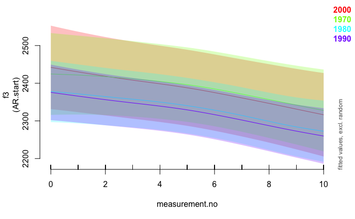

```r
R.m.baseline.full.plot <- plot_smooth(R.m.baseline.mod.AR, view="measurement.no", plot_all="decade",
            cond=list(stress="full"), rm.ranef=T, n.grid=100)$fv
```

```
Predictor decade is not a factor.
```

```
Summary:
    * stress : factor; set to the value(s): schwa.
    * avg.f3 : numeric predictor; set to the value(s): 2405.03714710253.
    * measurement.no : numeric predictor; with 100 values ranging from 0.000000 to 10.000000.
    * decade : numeric predictor; with 4 values ranging from 1970.000000 to 2000.000000.
    * duration : numeric predictor; set to the value(s): 0.122709575.
    * preceding.front : numeric predictor; set to the value(s): 1.
    * foll.broad.f3 : factor; set to the value(s): labial. (Might be canceled as random effect, check below.)
    * speaker : factor; set to the value(s): 00-O-m06. (Might be canceled as random effect, check below.)
    * word : factor; set to the value(s): were. (Might be canceled as random effect, check below.)
    * NOTE : The following random effects columns are canceled: s(measurement.no,foll.broad.f3),s(measurement.no,speaker),s(measurement.no,word)
```

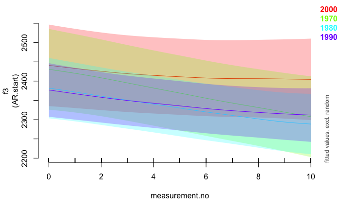

```r
R.m.baseline.schwa.plot <- plot_smooth(R.m.baseline.mod.AR, view="measurement.no", plot_all="decade",
            cond=list(stress="schwa"), rm.ranef=T, n.grid=100)$fv
```

```r
R.m.baseline.plot <- rbind(R.m.baseline.full.plot, R.m.baseline.schwa.plot)
R.m.baseline.plot$decade <- factor(R.m.baseline.plot$decade, levels=c("1970","1980","1990","2000"))

ggplot(R.m.baseline.plot, aes(x=measurement.no, y=fit, group=decade, col=decade, lty=decade)) +
  geom_line(lwd=1) +
  facet_grid(.~stress) +
  geom_ribbon(aes(ymin=ll, ymax=ul, group=decade), col=NA,col="grey", alpha=0.1) +
  #scale_color_manual(name="sex",breaks=c("F","M"), labels=c("female", "male"),
  #                   values=c("deepskyblue4","firebrick3")) +
  #scale_fill_manual(name="sex",breaks=c("F","M"), labels=c("female", "male"),
  #                   values=c("deepskyblue4","firebrick3"), guide=F) +
  #scale_x_discrete(name="decade of recording", labels=c(1970,1980,1990,2000), expand=expand_scale(add=c(0.05,1))) +
  scale_color_manual(name="decade of\nrecording", values=c("orange","darkorange3","deepskyblue1","deepskyblue4")) +
  scale_linetype_discrete(name="decade of\nrecording") +
  scale_x_continuous(name="measurement point", limits = c(0, 10), breaks=seq(0,10,2)) +
  scale_y_continuous(name="F3 (Hz)", limits=c(2000, 3050)) +
  theme_bw() +
  theme(axis.title = element_text(size=14),
        axis.text = element_text(size=12),
        legend.title = element_text(size=14, face="bold"),
        legend.text=element_text(size=12),
        plot.title=element_text(size=14, face="bold"),
        panel.grid=element_blank(),
        strip.text=element_text(size=12)) +
  ggtitle("F3 changes for /r/ in males (controlling for baseline F3)")
```

```
Duplicated aesthetics after name standardisation: colour
```

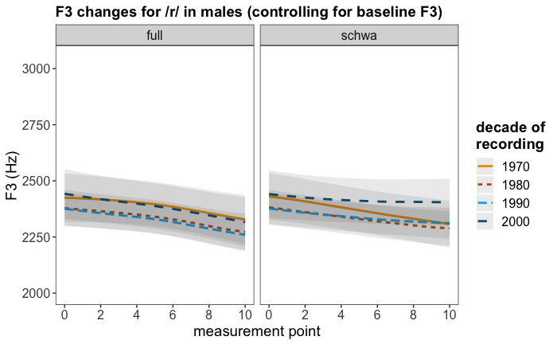

```r
ggsave("graphs/r_male_f3_change_control.pdf", width=8, height=4)
```

# Females, take 2 (with baseline control)

Fitting:

- model without AR for estimating rho
- full model with AR
- nested model with AR (rho from full model)

```r
if (refit_please) {
  system.time(
    R.f.baseline.mod.no.AR <- bam(f3 ~ stress +
                          avg.f3 +
                       # level 1 smooth terms
                          s(measurement.no) +
                          s(decade, k=4) +
                          s(duration) +
                          s(preceding.front, k=3) +
                       # level 2: by terms
                          s(measurement.no, by=stress) +
                          s(decade, k=4, by=stress) +
                       # level 2: 2d smooths
                          ti(measurement.no, decade, k=c(10,4)) +
                          ti(measurement.no, duration) +
                          ti(measurement.no, preceding.front, k=c(10,3)) +
                       # level 3: 2d smooth by terms
                          ti(measurement.no, decade, k=c(10,4), by=stress) +
                       # random smooths
                          s(measurement.no, foll.broad.f3, bs="fs", m=1, k=4) +
                          s(measurement.no, speaker, bs="fs", m=1, k=4) +
                          s(measurement.no, word, bs="fs", m=1, k=4),
                      dat=R.f)
  )
  # saveRDS(R.f.baseline.mod.no.AR, "models/R.f.baseline.mod.no.AR")

  R.f.baseline.rho <- start_value_rho(R.f.baseline.mod.no.AR)

  system.time(
    R.f.baseline.mod.AR <- bam(f3 ~ stress +
                          avg.f3 +
                       # level 1 smooth terms
                          s(measurement.no) +
                          s(decade, k=4) +
                          s(duration) +
                          s(preceding.front, k=3) +
                       # level 2: by terms
                          s(measurement.no, by=stress) +
                          s(decade, k=4, by=stress) +
                       # level 2: 2d smooths
                          ti(measurement.no, decade, k=c(10,4)) +
                          ti(measurement.no, duration) +
                          ti(measurement.no, preceding.front, k=c(10,3)) +
                       # level 3: 2d smooth by terms
                          ti(measurement.no, decade, k=c(10,4), by=stress) +
                       # random smooths
                          s(measurement.no, foll.broad.f3, bs="fs", m=1, k=4) +
                          s(measurement.no, speaker, bs="fs", m=1, k=4) +
                          s(measurement.no, word, bs="fs", m=1, k=4),
                      dat=R.f, method="ML",
                      AR.start=R.f$start.event, rho=R.f.baseline.rho)
  )
  # saveRDS(R.f.baseline.mod.AR, "models/R.f.baseline.mod.AR")

  summary(R.f.baseline.mod.AR)

  system.time(
    R.f.baseline.mod.AR.min.decade <- bam(f3 ~ stress +
                          avg.f3 +
                       # level 1 smooth terms
                          s(measurement.no) +
                          #s(decade, k=4) +
                          s(duration) +
                          s(preceding.front, k=3) +
                       # level 2: by terms
                          s(measurement.no, by=stress) +
                          #s(decade, k=4, by=stress) +
                       # level 2: 2d smooths
                          #ti(measurement.no, decade, k=c(10,4)) +
                          ti(measurement.no, duration) +
                          ti(measurement.no, preceding.front, k=c(10,3)) +
                       # level 3: 2d smooth by terms
                          #ti(measurement.no, decade, k=c(10,4), by=stress) +
                       # random smooths
                          s(measurement.no, foll.broad.f3, bs="fs", m=1, k=4) +
                          s(measurement.no, speaker, bs="fs", m=1, k=4) +
                          s(measurement.no, word, bs="fs", m=1, k=4),
                      dat=R.f, method="ML",
                      AR.start=R.f$start.event, rho=R.f.baseline.rho)
  )
  # saveRDS(R.f.baseline.mod.AR.min.decade, "models/R.f.baseline.mod.AR.min.decade")
}
R.f.baseline.mod.no.AR <- readRDS("models/R.f.baseline.mod.no.AR")
R.f.baseline.mod.AR <- readRDS("models/R.f.baseline.mod.AR")
R.f.baseline.mod.AR.min.decade <- readRDS("models/R.f.baseline.mod.AR.min.decade")
compareML(R.f.baseline.mod.AR, R.f.baseline.mod.AR.min.decade)
```

```
R.f.baseline.mod.AR: f3 ~ stress + avg.f3 + s(measurement.no) + s(decade, k = 4) +
    s(duration) + s(preceding.front, k = 3) + s(measurement.no,
    by = stress) + s(decade, k = 4, by = stress) + ti(measurement.no,
    decade, k = c(10, 4)) + ti(measurement.no, duration) + ti(measurement.no,
    preceding.front, k = c(10, 3)) + ti(measurement.no, decade,
    k = c(10, 4), by = stress) + s(measurement.no, foll.broad.f3,
    bs = "fs", m = 1, k = 4) + s(measurement.no, speaker, bs = "fs",
    m = 1, k = 4) + s(measurement.no, word, bs = "fs", m = 1,
    k = 4)

R.f.baseline.mod.AR.min.decade: f3 ~ stress + avg.f3 + s(measurement.no) + s(duration) + s(preceding.front,
    k = 3) + s(measurement.no, by = stress) + ti(measurement.no,
    duration) + ti(measurement.no, preceding.front, k = c(10,
    3)) + s(measurement.no, foll.broad.f3, bs = "fs", m = 1,
    k = 4) + s(measurement.no, speaker, bs = "fs", m = 1, k = 4) +
    s(measurement.no, word, bs = "fs", m = 1, k = 4)

Chi-square test of ML scores
-----
```

| Model | Score | Edf | Difference | Df | p.value | Sig. |
| --- | --- | --- | --- | --- | --- | --- |
| R.f.baseline.mod.AR.min.decade | 25884.98 | 23 |  |  |  |  |
| R.f.baseline.mod.AR | 25874.10 | 33 | 10.876 | 10.000 | 0.016 | * |

```
AIC difference: -7.88, model R.f.baseline.mod.AR has lower AIC.
```

```
 AIC might not be reliable, as an AR1 model is included (rho1 = 0.850645, rho2 = 0.850645).
```

```
Predictor decade is not a factor.
```

```
Summary:
    * stress : factor; set to the value(s): full.
    * avg.f3 : numeric predictor; set to the value(s): 2717.01597051597.
    * measurement.no : numeric predictor; with 30 values ranging from 0.000000 to 10.000000.
    * decade : numeric predictor; with 4 values ranging from 1970.000000 to 2000.000000.
    * duration : numeric predictor; set to the value(s): 0.103923377.
    * preceding.front : numeric predictor; set to the value(s): 1.
    * foll.broad.f3 : factor; set to the value(s): coronal. (Might be canceled as random effect, check below.)
    * speaker : factor; set to the value(s): 00-O-f01. (Might be canceled as random effect, check below.)
    * word : factor; set to the value(s): were. (Might be canceled as random effect, check below.)
    * NOTE : The following random effects columns are canceled: s(measurement.no,foll.broad.f3),s(measurement.no,speaker),s(measurement.no,word)
```

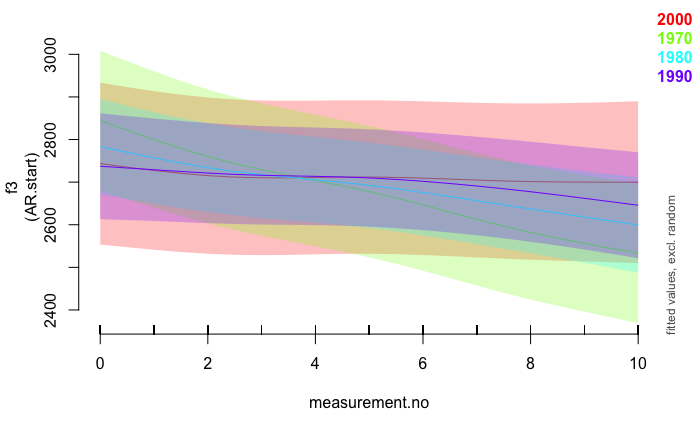

```r
plot_smooth(R.f.baseline.mod.AR, view="measurement.no", plot_all="decade",
            cond=list(stress="full"), rm.ranef=T)
```

```
Predictor decade is not a factor.
```

```
Summary:
    * stress : factor; set to the value(s): schwa.
    * avg.f3 : numeric predictor; set to the value(s): 2717.01597051597.
    * measurement.no : numeric predictor; with 30 values ranging from 0.000000 to 10.000000.
    * decade : numeric predictor; with 4 values ranging from 1970.000000 to 2000.000000.
    * duration : numeric predictor; set to the value(s): 0.103923377.
    * preceding.front : numeric predictor; set to the value(s): 1.
    * foll.broad.f3 : factor; set to the value(s): coronal. (Might be canceled as random effect, check below.)
    * speaker : factor; set to the value(s): 00-O-f01. (Might be canceled as random effect, check below.)
    * word : factor; set to the value(s): were. (Might be canceled as random effect, check below.)
    * NOTE : The following random effects columns are canceled: s(measurement.no,foll.broad.f3),s(measurement.no,speaker),s(measurement.no,word)
```

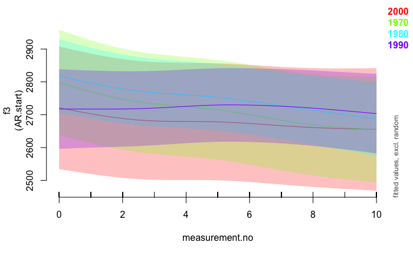

```r
plot_smooth(R.f.baseline.mod.AR, view="measurement.no", plot_all="decade",
            cond=list(stress="schwa"), rm.ranef=T)
```

Further questions:

- overall effect of stress?
- significant change in shape?
- do unstressed / stressed syllables show different changes?
- different shape change?
- different overall change?

```r
if (refit_please) {
  # overall stress?
  system.time(
    R.f.baseline.mod.AR.min.stress <- bam(f3 ~ #stress +
                          avg.f3 +
                       # level 1 smooth terms
                          s(measurement.no) +
                          s(decade, k=4) +
                          s(duration) +
                          s(preceding.front, k=3) +
                       # level 2: by terms
                          #s(measurement.no, by=stress) +
                          #s(decade, k=4, by=stress) +
                       # level 2: 2d smooths
                          ti(measurement.no, decade, k=c(10,4)) +
                          ti(measurement.no, duration) +
                          ti(measurement.no, preceding.front, k=c(10,3)) +
                       # level 3: 2d smooth by terms
                          #ti(measurement.no, decade, k=c(10,4), by=stress) +
                       # random smooths
                          s(measurement.no, foll.broad.f3, bs="fs", m=1, k=4) +
                          s(measurement.no, speaker, bs="fs", m=1, k=4) +
                          s(measurement.no, word, bs="fs", m=1, k=4),
                      dat=R.f, method="ML",
                      AR.start=R.f$start.event, rho=R.f.baseline.rho)
  )
  saveRDS(R.f.baseline.mod.AR.min.stress, "models/R.f.baseline.mod.AR.min.stress")
  # shape change?
  system.time(
    R.f.baseline.mod.AR.min.decade.shape <- bam(f3 ~ stress +
                          avg.f3 +
                       # level 1 smooth terms
                          s(measurement.no) +
                          s(decade, k=4) +
                          s(duration) +
                          s(preceding.front, k=3) +
                       # level 2: by terms
                          s(measurement.no, by=stress) +
                          s(decade, k=4, by=stress) +
                       # level 2: 2d smooths
                          #ti(measurement.no, decade, k=c(10,4)) +
                          ti(measurement.no, duration) +
                          ti(measurement.no, preceding.front, k=c(10,3)) +
                       # level 3: 2d smooth by terms
                          #ti(measurement.no, decade, k=c(10,4), by=stress) +
                       # random smooths
                          s(measurement.no, foll.broad.f3, bs="fs", m=1, k=4) +
                          s(measurement.no, speaker, bs="fs", m=1, k=4) +
                          s(measurement.no, word, bs="fs", m=1, k=4),
                      dat=R.f, method="ML",
                      AR.start=R.f$start.event, rho=R.f.baseline.rho)
  )
  saveRDS(R.f.baseline.mod.AR.min.decade.shape, "models/R.f.baseline.mod.AR.min.decade.shape")
  # overall stress x decade?
  system.time(
    R.f.baseline.mod.AR.min.decade.stress <- bam(f3 ~ stress +
                          avg.f3 +
                       # level 1 smooth terms
                          s(measurement.no) +
                          s(decade, k=4) +
                          s(duration) +
                          s(preceding.front, k=3) +
                       # level 2: by terms
                          s(measurement.no, by=stress) +
                          #s(decade, k=4, by=stress) +
                       # level 2: 2d smooths
                          ti(measurement.no, decade, k=c(10,4)) +
                          ti(measurement.no, duration) +
                          ti(measurement.no, preceding.front, k=c(10,3)) +
                       # level 3: 2d smooth by terms
                          #ti(measurement.no, decade, k=c(10,4), by=stress) +
                       # random smooths
                          s(measurement.no, foll.broad.f3, bs="fs", m=1, k=4) +
                          s(measurement.no, speaker, bs="fs", m=1, k=4) +
                          s(measurement.no, word, bs="fs", m=1, k=4),
                      dat=R.f, method="ML",
                      AR.start=R.f$start.event, rho=R.f.baseline.rho)
  )
  saveRDS(R.f.baseline.mod.AR.min.decade.stress, "models/R.f.baseline.mod.AR.min.decade.stress")

  # shape stress x decade?

  system.time(
    R.f.baseline.mod.AR.min.decade.stress.shape <- bam(f3 ~ stress +
                          avg.f3 +
                       # level 1 smooth terms
                          s(measurement.no) +
                          s(decade, k=4) +
                          s(duration) +
                          s(preceding.front, k=3) +
                       # level 2: by terms
                          s(measurement.no, by=stress) +
                          s(decade, k=4, by=stress) +
                       # level 2: 2d smooths
                          ti(measurement.no, decade, k=c(10,4)) +
                          ti(measurement.no, duration) +
                          ti(measurement.no, preceding.front, k=c(10,3)) +
                       # level 3: 2d smooth by terms
                          #ti(measurement.no, decade, k=c(10,4), by=stress) +
                       # random smooths
                          s(measurement.no, foll.broad.f3, bs="fs", m=1, k=4) +
                          s(measurement.no, speaker, bs="fs", m=1, k=4) +
                          s(measurement.no, word, bs="fs", m=1, k=4),
                      dat=R.f, method="ML",
                      AR.start=R.f$start.event, rho=R.f.baseline.rho)
  )
  saveRDS(R.f.baseline.mod.AR.min.decade.stress.shape, "models/R.f.baseline.mod.AR.min.decade.stress.shape")
}

R.f.baseline.mod.AR.min.stress <- readRDS("models/R.f.baseline.mod.AR.min.stress")
R.f.baseline.mod.AR.min.decade.shape <- readRDS("models/R.f.baseline.mod.AR.min.decade.shape")
R.f.baseline.mod.AR.min.decade.stress <- readRDS("models/R.f.baseline.mod.AR.min.decade.stress")
R.f.baseline.mod.AR.min.decade.stress.shape <- readRDS("models/R.f.baseline.mod.AR.min.decade.stress.shape")
# overall stress?
compareML(R.f.baseline.mod.AR, R.f.baseline.mod.AR.min.stress, suggest.report=T) # non-sig
```

```
R.f.baseline.mod.AR: f3 ~ stress + avg.f3 + s(measurement.no) + s(decade, k = 4) +
    s(duration) + s(preceding.front, k = 3) + s(measurement.no,
    by = stress) + s(decade, k = 4, by = stress) + ti(measurement.no,
    decade, k = c(10, 4)) + ti(measurement.no, duration) + ti(measurement.no,
    preceding.front, k = c(10, 3)) + ti(measurement.no, decade,
    k = c(10, 4), by = stress) + s(measurement.no, foll.broad.f3,
    bs = "fs", m = 1, k = 4) + s(measurement.no, speaker, bs = "fs",
    m = 1, k = 4) + s(measurement.no, word, bs = "fs", m = 1,
    k = 4)

R.f.baseline.mod.AR.min.stress: f3 ~ avg.f3 + s(measurement.no) + s(decade, k = 4) + s(duration) +
    s(preceding.front, k = 3) + ti(measurement.no, decade, k = c(10,
    4)) + ti(measurement.no, duration) + ti(measurement.no, preceding.front,
    k = c(10, 3)) + s(measurement.no, foll.broad.f3, bs = "fs",
    m = 1, k = 4) + s(measurement.no, speaker, bs = "fs", m = 1,
    k = 4) + s(measurement.no, word, bs = "fs", m = 1, k = 4)

Report suggestion: The Chi-Square test on the ML scores indicates that model R.f.baseline.mod.AR is [marginally / significantly?] better than model R.f.baseline.mod.AR.min.stress (X2(8.00)=9.527, p0.015).
-----
```

| Model | Score | Edf | Difference | Df | p.value | Sig. |
| --- | --- | --- | --- | --- | --- | --- |
| R.f.baseline.mod.AR.min.stress | 25883.63 | 25 |  |  |  |  |
| R.f.baseline.mod.AR | 25874.10 | 33 | 9.527 | 8.000 | 0.015 | * |

```
AIC difference: -2.57, model R.f.baseline.mod.AR has lower AIC.
```

```
 AIC might not be reliable, as an AR1 model is included (rho1 = 0.850645, rho2 = 0.850645).
```

```r
# shape change?
compareML(R.f.baseline.mod.AR, R.f.baseline.mod.AR.min.decade.shape, suggest.report=T) # non-sig
```

```
R.f.baseline.mod.AR: f3 ~ stress + avg.f3 + s(measurement.no) + s(decade, k = 4) +
    s(duration) + s(preceding.front, k = 3) + s(measurement.no,
    by = stress) + s(decade, k = 4, by = stress) + ti(measurement.no,
    decade, k = c(10, 4)) + ti(measurement.no, duration) + ti(measurement.no,
    preceding.front, k = c(10, 3)) + ti(measurement.no, decade,
    k = c(10, 4), by = stress) + s(measurement.no, foll.broad.f3,
    bs = "fs", m = 1, k = 4) + s(measurement.no, speaker, bs = "fs",
    m = 1, k = 4) + s(measurement.no, word, bs = "fs", m = 1,
    k = 4)

R.f.baseline.mod.AR.min.decade.shape: f3 ~ stress + avg.f3 + s(measurement.no) + s(decade, k = 4) +
    s(duration) + s(preceding.front, k = 3) + s(measurement.no,
    by = stress) + s(decade, k = 4, by = stress) + ti(measurement.no,
    duration) + ti(measurement.no, preceding.front, k = c(10,
    3)) + s(measurement.no, foll.broad.f3, bs = "fs", m = 1,
    k = 4) + s(measurement.no, speaker, bs = "fs", m = 1, k = 4) +
    s(measurement.no, word, bs = "fs", m = 1, k = 4)

Report suggestion: The Chi-Square test on the ML scores indicates that model R.f.baseline.mod.AR is [marginally / significantly?] better than model R.f.baseline.mod.AR.min.decade.shape (X2(6.00)=8.079, p0.013).
-----
```

| Model | Score | Edf | Difference | Df | p.value | Sig. |
| --- | --- | --- | --- | --- | --- | --- |
| R.f.baseline.mod.AR.min.decade.shape | 25882.18 | 27 |  |  |  |  |
| R.f.baseline.mod.AR | 25874.10 | 33 | 8.079 | 6.000 | 0.013 | * |

```
AIC difference: -8.39, model R.f.baseline.mod.AR has lower AIC.
```

```
 AIC might not be reliable, as an AR1 model is included (rho1 = 0.850645, rho2 = 0.850645).
```

```r
# overall stress x decade?
compareML(R.f.baseline.mod.AR, R.f.baseline.mod.AR.min.decade.stress, suggest.report=T) # non-sig
```

```
R.f.baseline.mod.AR: f3 ~ stress + avg.f3 + s(measurement.no) + s(decade, k = 4) +
    s(duration) + s(preceding.front, k = 3) + s(measurement.no,
    by = stress) + s(decade, k = 4, by = stress) + ti(measurement.no,
    decade, k = c(10, 4)) + ti(measurement.no, duration) + ti(measurement.no,
    preceding.front, k = c(10, 3)) + ti(measurement.no, decade,
    k = c(10, 4), by = stress) + s(measurement.no, foll.broad.f3,
    bs = "fs", m = 1, k = 4) + s(measurement.no, speaker, bs = "fs",
    m = 1, k = 4) + s(measurement.no, word, bs = "fs", m = 1,
    k = 4)

R.f.baseline.mod.AR.min.decade.stress: f3 ~ stress + avg.f3 + s(measurement.no) + s(decade, k = 4) +
    s(duration) + s(preceding.front, k = 3) + s(measurement.no,
    by = stress) + ti(measurement.no, decade, k = c(10, 4)) +
    ti(measurement.no, duration) + ti(measurement.no, preceding.front,
    k = c(10, 3)) + s(measurement.no, foll.broad.f3, bs = "fs",
    m = 1, k = 4) + s(measurement.no, speaker, bs = "fs", m = 1,
    k = 4) + s(measurement.no, word, bs = "fs", m = 1, k = 4)

Report suggestion: The Chi-Square test on the ML scores indicates that model R.f.baseline.mod.AR is [marginally / significantly?] better than model R.f.baseline.mod.AR.min.decade.stress (X2(5.00)=7.106, p0.014).
-----
```

| Model | Score | Edf | Difference | Df | p.value | Sig. |
| --- | --- | --- | --- | --- | --- | --- |
| R.f.baseline.mod.AR.min.decade.stress | 25881.21 | 28 |  |  |  |  |
| R.f.baseline.mod.AR | 25874.10 | 33 | 7.106 | 5.000 | 0.014 | * |

```
AIC difference: -4.93, model R.f.baseline.mod.AR has lower AIC.
```

```
 AIC might not be reliable, as an AR1 model is included (rho1 = 0.850645, rho2 = 0.850645).
```

```r
# shape stress x decade?
compareML(R.f.baseline.mod.AR, R.f.baseline.mod.AR.min.decade.stress.shape) # non-sig
```

```
R.f.baseline.mod.AR: f3 ~ stress + avg.f3 + s(measurement.no) + s(decade, k = 4) +
    s(duration) + s(preceding.front, k = 3) + s(measurement.no,
    by = stress) + s(decade, k = 4, by = stress) + ti(measurement.no,
    decade, k = c(10, 4)) + ti(measurement.no, duration) + ti(measurement.no,
    preceding.front, k = c(10, 3)) + ti(measurement.no, decade,
    k = c(10, 4), by = stress) + s(measurement.no, foll.broad.f3,
    bs = "fs", m = 1, k = 4) + s(measurement.no, speaker, bs = "fs",
    m = 1, k = 4) + s(measurement.no, word, bs = "fs", m = 1,
    k = 4)

R.f.baseline.mod.AR.min.decade.stress.shape: f3 ~ stress + avg.f3 + s(measurement.no) + s(decade, k = 4) +
    s(duration) + s(preceding.front, k = 3) + s(measurement.no,
    by = stress) + s(decade, k = 4, by = stress) + ti(measurement.no,
    decade, k = c(10, 4)) + ti(measurement.no, duration) + ti(measurement.no,
    preceding.front, k = c(10, 3)) + s(measurement.no, foll.broad.f3,
    bs = "fs", m = 1, k = 4) + s(measurement.no, speaker, bs = "fs",
    m = 1, k = 4) + s(measurement.no, word, bs = "fs", m = 1,
    k = 4)

Chi-square test of ML scores
-----
```

| Model | Score | Edf | Difference | Df | p.value | Sig. |
| --- | --- | --- | --- | --- | --- | --- |
| R.f.baseline.mod.AR.min.decade.stress.shape | 25878.36 | 30 |  |  |  |  |
| R.f.baseline.mod.AR | 25874.10 | 33 | 4.254 | 3.000 | 0.037 | * |

```
AIC difference: -4.60, model R.f.baseline.mod.AR has lower AIC.
```

```
 AIC might not be reliable, as an AR1 model is included (rho1 = 0.850645, rho2 = 0.850645). Only small difference in ML...
```

Make a pretty graph for the female predictions.

```
Predictor decade is not a factor.
```

```
Summary:
    * stress : factor; set to the value(s): full.
    * avg.f3 : numeric predictor; set to the value(s): 2717.01597051597.
    * measurement.no : numeric predictor; with 100 values ranging from 0.000000 to 10.000000.
    * decade : numeric predictor; with 4 values ranging from 1970.000000 to 2000.000000.
    * duration : numeric predictor; set to the value(s): 0.103923377.
    * preceding.front : numeric predictor; set to the value(s): 1.
    * foll.broad.f3 : factor; set to the value(s): coronal. (Might be canceled as random effect, check below.)
    * speaker : factor; set to the value(s): 00-O-f01. (Might be canceled as random effect, check below.)
    * word : factor; set to the value(s): were. (Might be canceled as random effect, check below.)
    * NOTE : The following random effects columns are canceled: s(measurement.no,foll.broad.f3),s(measurement.no,speaker),s(measurement.no,word)
```

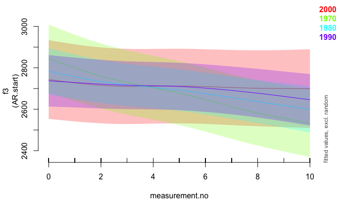

```r
R.f.baseline.full.plot <- plot_smooth(R.f.baseline.mod.AR, view="measurement.no", plot_all="decade",
            cond=list(stress="full"), rm.ranef=T, n.grid=100)$fv
```

```
Predictor decade is not a factor.
```

```
Summary:
    * stress : factor; set to the value(s): schwa.
    * avg.f3 : numeric predictor; set to the value(s): 2717.01597051597.
    * measurement.no : numeric predictor; with 100 values ranging from 0.000000 to 10.000000.
    * decade : numeric predictor; with 4 values ranging from 1970.000000 to 2000.000000.
    * duration : numeric predictor; set to the value(s): 0.103923377.
    * preceding.front : numeric predictor; set to the value(s): 1.
    * foll.broad.f3 : factor; set to the value(s): coronal. (Might be canceled as random effect, check below.)
    * speaker : factor; set to the value(s): 00-O-f01. (Might be canceled as random effect, check below.)
    * word : factor; set to the value(s): were. (Might be canceled as random effect, check below.)
    * NOTE : The following random effects columns are canceled: s(measurement.no,foll.broad.f3),s(measurement.no,speaker),s(measurement.no,word)
```

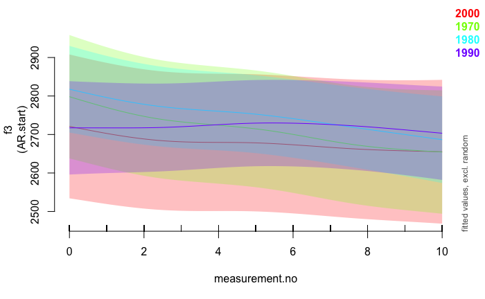

```r
R.f.baseline.schwa.plot <- plot_smooth(R.f.baseline.mod.AR, view="measurement.no", plot_all="decade",
            cond=list(stress="schwa"), rm.ranef=T, n.grid=100)$fv
```

```r
R.f.baseline.plot <- rbind(R.f.baseline.full.plot, R.f.baseline.schwa.plot)
R.f.baseline.plot$decade <- factor(R.f.baseline.plot$decade, levels=c("1970","1980","1990","2000"))

ggplot(R.f.baseline.plot, aes(x=measurement.no, y=fit, group=decade, col=decade, lty=decade)) +
  geom_line(lwd=1) +
  facet_grid(.~stress) +
  geom_ribbon(aes(ymin=ll, ymax=ul, group=decade), col=NA,col="grey", alpha=0.1) +
  #scale_color_manual(name="sex",breaks=c("F","M"), labels=c("female", "male"),
  #                   values=c("deepskyblue4","firebrick3")) +
  #scale_fill_manual(name="sex",breaks=c("F","M"), labels=c("female", "male"),
  #                   values=c("deepskyblue4","firebrick3"), guide=F) +
  #scale_x_discrete(name="decade of recording", labels=c(1970,1980,1990,2000), expand=expand_scale(add=c(0.05,1))) +
  scale_color_manual(name="decade of\nrecording", values=c("orange","darkorange3","deepskyblue1","deepskyblue4")) +
  scale_linetype_discrete(name="decade of\nrecording") +
  scale_x_continuous(name="measurement point", limits = c(0, 10), breaks=seq(0,10,2)) +
  scale_y_continuous(name="F3 (Hz)", limits=c(2000, 3050)) +
  theme_bw() +
  theme(axis.title = element_text(size=14),
        axis.text = element_text(size=12),
        legend.title = element_text(size=14, face="bold"),
        legend.text=element_text(size=12),
        plot.title=element_text(size=14, face="bold"),
        panel.grid=element_blank(),
        strip.text=element_text(size=12)) +
  ggtitle("F3 changes for /r/ in females (controlling for baseline F3)")
```

```
Duplicated aesthetics after name standardisation: colour
```

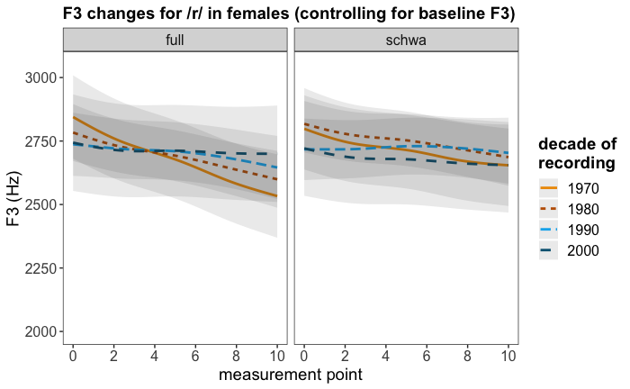

```r
ggsave("graphs/r_female_f3_change_control.pdf", width=8, height=4)
```

## Auditory analysis of R realisations

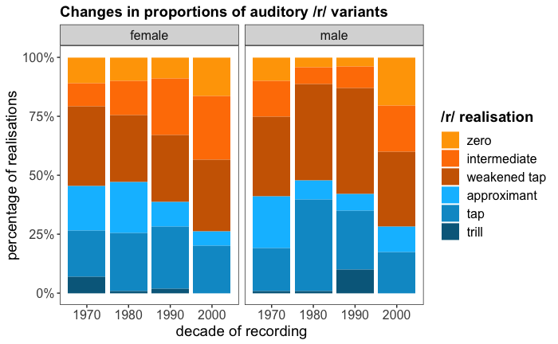

Let’s run some logistic regression models…

```r
anova(r.str.mod, r.str.mod.min.decade,test="Chisq")
```

```
Data: R.aud
Models:
r.str.mod.min.decade: r.strength ~ gender + stress + (1 | speaker) + (1 | word)
r.str.mod: r.strength ~ scale(decade) * gender + stress + (1 | speaker) +
r.str.mod:     (1 | word)
                     Df    AIC    BIC  logLik deviance  Chisq Chi Df Pr(>Chisq)
r.str.mod.min.decade  5 1030.3 1053.7 -510.14   1020.3
r.str.mod             7 1031.4 1064.2 -508.70   1017.4 2.8712      2      0.238
```

Nothing really significant here, and these are slightly anti-conservative models, so no point in pushing this any further.

How about the phonetics of different R variants? Modelling F3 as a function of variant type should do the trick…

```r
R <- mutate(R, trans.broad=recode(trans, wa="a"))
R <- R[!(R$trans %in% c("", "?r")),]
R$trans.broad.fact <- as.ordered(R$trans.broad)
contrasts(R$trans.broad.fact) <- "contr.treatment"
R$gender <- as.ordered(R$gender)
contrasts(R$gender) <- "contr.treatment"
if (refit_please) {
  system.time(
    R.shapes.mod.no.AR <- bam(f3 ~ stress + trans.broad.fact + gender +
                       # level 1 smooth terms
                          s(measurement.no) +
                          s(duration) +
                          s(preceding.front, k=3) +
                       # level 2: by terms
                          s(measurement.no, by=stress) +
                          s(measurement.no, by=trans.broad.fact) +
                          s(measurement.no, by=gender) +
                       # level 2: 2d smooths
                          ti(measurement.no, duration) +
                          ti(measurement.no, preceding.front, k=c(10,3)) +
                       # random smooths
                          s(measurement.no, foll.broad.f3, bs="fs", m=1, k=4) +
                          s(measurement.no, speaker, bs="fs", m=1, k=4) +
                          s(measurement.no, word, bs="fs", m=1, k=4),
                      dat=R)
  )
  saveRDS(R.shapes.mod.no.AR, "models/R.shapes.mod.no.AR")

  R.shapes.rho <- start_value_rho(R.shapes.mod.no.AR)
  R$start.event <- R$measurement.no == 0

  system.time(
    R.shapes.mod.AR   <- bam(f3 ~ stress + trans.broad.fact + gender +
                       # level 1 smooth terms
                          s(measurement.no) +
                          s(duration) +
                          s(preceding.front, k=3) +
                       # level 2: by terms
                          s(measurement.no, by=stress) +
                          s(measurement.no, by=trans.broad.fact) +
                          s(measurement.no, by=gender) +
                       # level 2: 2d smooths
                          ti(measurement.no, duration) +
                          ti(measurement.no, preceding.front, k=c(10,3)) +
                       # random smooths
                          s(measurement.no, foll.broad.f3, bs="fs", m=1, k=4) +
                          s(measurement.no, speaker, bs="fs", m=1, k=4) +
                          s(measurement.no, word, bs="fs", m=1, k=4),
                      dat=R,
                      AR.start=R$start.event, rho=R.shapes.rho,
                      method="ML")
  )
  saveRDS(R.shapes.mod.AR, "models/R.shapes.mod.AR")

  summary(R.shapes.mod.AR)

  system.time(
    R.shapes.mod.AR.min.trans   <- bam(f3 ~ stress + gender + # trans.broad.fact +
                       # level 1 smooth terms
                          s(measurement.no) +
                          s(duration) +
                          s(preceding.front, k=3) +
                       # level 2: by terms
                          s(measurement.no, by=stress) +
                          #s(measurement.no, by=trans.broad.fact) +
                          s(measurement.no, by=gender) +
                       # level 2: 2d smooths
                          ti(measurement.no, duration) +
                          ti(measurement.no, preceding.front, k=c(10,3)) +
                       # random smooths
                          s(measurement.no, foll.broad.f3, bs="fs", m=1, k=4) +
                          s(measurement.no, speaker, bs="fs", m=1, k=4) +
                          s(measurement.no, word, bs="fs", m=1, k=4),
                      dat=R,
                      AR.start=R$start.event, rho=R.shapes.rho,
                      method="ML")
  )
  saveRDS(R.shapes.mod.AR.min.trans, "models/R.shapes.mod.AR.min.trans")
}
#summary(R.shapes.mod.AR.min.trans)
R.shapes.mod.no.AR <- readRDS("models/R.shapes.mod.no.AR")
R.shapes.mod.AR <- readRDS("models/R.shapes.mod.AR")
R.shapes.mod.AR.min.trans <- readRDS("models/R.shapes.mod.AR.min.trans")
compareML(R.shapes.mod.AR, R.shapes.mod.AR.min.trans)
```

```
R.shapes.mod.AR: f3 ~ stress + trans.broad.fact + gender + s(measurement.no) +
    s(duration) + s(preceding.front, k = 3) + s(measurement.no,
    by = stress) + s(measurement.no, by = trans.broad.fact) +
    s(measurement.no, by = gender) + ti(measurement.no, duration) +
    ti(measurement.no, preceding.front, k = c(10, 3)) + s(measurement.no,
    foll.broad.f3, bs = "fs", m = 1, k = 4) + s(measurement.no,
    speaker, bs = "fs", m = 1, k = 4) + s(measurement.no, word,
    bs = "fs", m = 1, k = 4)

R.shapes.mod.AR.min.trans: f3 ~ stress + gender + s(measurement.no) + s(duration) + s(preceding.front,
    k = 3) + s(measurement.no, by = stress) + s(measurement.no,
    by = gender) + ti(measurement.no, duration) + ti(measurement.no,
    preceding.front, k = c(10, 3)) + s(measurement.no, foll.broad.f3,
    bs = "fs", m = 1, k = 4) + s(measurement.no, speaker, bs = "fs",
    m = 1, k = 4) + s(measurement.no, word, bs = "fs", m = 1,
    k = 4)

Chi-square test of ML scores
-----
```

| Model | Score | Edf | Difference | Df | p.value | Sig. |
| --- | --- | --- | --- | --- | --- | --- |
| R.shapes.mod.AR.min.trans | 50868.40 | 25 |  |  |  |  |
| R.shapes.mod.AR | 50752.83 | 40 | 115.567 | 15.000 | < 2e-16 | *** |

```
AIC difference: -192.66, model R.shapes.mod.AR has lower AIC.
```

```
 AIC might not be reliable, as an AR1 model is included (rho1 = 0.860217, rho2 = 0.860217).
```

```r
#plot_smooth(R.shapes.mod.AR, view="measurement.no", plot_all="trans.broad.fact",
#            rm.ranef=T, rug=F, se=0)
```

Pretty plot for paper:

```
Summary:
    * stress : factor; set to the value(s): schwa.
    * trans.broad.fact : factor; set to the value(s): a, i, o, r, t, wt.
    * gender : factor; set to the value(s): F.
    * measurement.no : numeric predictor; with 30 values ranging from 0.000000 to 10.000000.
    * duration : numeric predictor; set to the value(s): 0.11452771.
    * preceding.front : numeric predictor; set to the value(s): 1.
    * foll.broad.f3 : factor; set to the value(s): labial. (Might be canceled as random effect, check below.)
    * speaker : factor; set to the value(s): 00-O-f01. (Might be canceled as random effect, check below.)
    * word : factor; set to the value(s): were. (Might be canceled as random effect, check below.)
    * NOTE : The following random effects columns are canceled: s(measurement.no,foll.broad.f3),s(measurement.no,speaker),s(measurement.no,word)
```

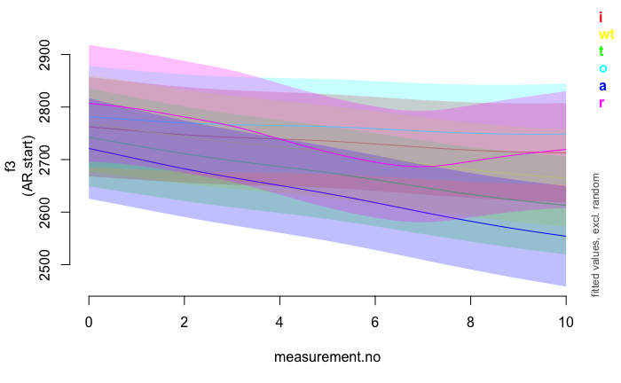

```r
R.shapes <- plot_smooth(R.shapes.mod.AR, view="measurement.no", plot_all="trans.broad.fact",
                        cond=list(gender="F"), rm.ranef=T, rug=F)[[1]]
```

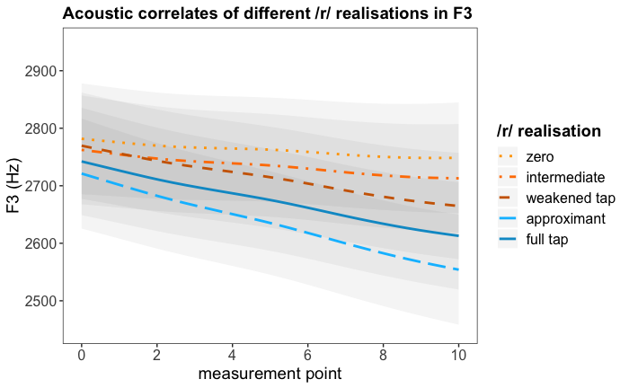

```r
R.shapes$trans.broad.fact <- factor(R.shapes$trans.broad.fact, levels=c("o","i","wt","a","t","r"))
R.shapes <- R.shapes %>%
  mutate(realisation=recode(trans.broad.fact,
                            o="zero",
                            i="intermediate",
                            wt="weakened tap",
                            a="approximant",
                            t="full tap",
                            r="trill"),
         realisation=factor(realisation,
                            levels=c("zero",
                                     "intermediate",
                                     "weakened tap",
                                     "approximant",
                                     "full tap",
                                     "trill"))
  )
R.shapes <- filter(R.shapes, trans.broad.fact != "r")
ggplot(R.shapes, aes(x=measurement.no, y=fit, col=realisation, lty=realisation)) +
  geom_ribbon(aes(ymin=ll, ymax=ul, group=trans.broad.fact), alpha=0.05, colour=NA) +
  geom_line(lwd=1) +
  scale_linetype_manual(values = c(3,4,2,
                              5,1),
                     name="/r/ realisation") +
  scale_colour_manual(values = c("orange","darkorange1",
                               "darkorange3","deepskyblue1",
                               "deepskyblue3"),
                      name="/r/ realisation") +
  scale_x_continuous(name="measurement point", limits = c(0, 10), breaks=seq(0,10,2)) +
  scale_y_continuous(name="F3 (Hz)", limits=c(2450,2950)) +
  theme_bw() +
  theme(axis.title = element_text(size=14),
        axis.text = element_text(size=12),
        legend.title = element_text(size=14, face="bold"),
        legend.text=element_text(size=12),
        plot.title=element_text(size=14, face="bold"),
        panel.grid=element_blank(),
        strip.text=element_text(size=12)) +
  ggtitle("Acoustic correlates of different /r/ realisations in F3")
ggsave("graphs/r_acoustic_correlates.pdf", width=6, height=4)
```

## Auditory VQ analysis

```r
summary(lm(advanced.tip.blade ~ decade.centred + gender.sum, data=R.vq))
```

```
Call:
lm(formula = advanced.tip.blade ~ decade.centred + gender.sum,
    data = R.vq)

Residuals:
     Min       1Q   Median       3Q      Max
-0.75535 -0.54625 -0.00076  0.40826  0.99924

Coefficients:
               Estimate Std. Error t value Pr(>|t|)
(Intercept)     1.58716    0.12417  12.783 4.42e-11 ***
decade.centred -0.00818    0.01091  -0.750    0.462
gender.sum1     0.04549    0.12417   0.366    0.718
---
Signif. codes:  0 ‘***’ 0.001 ‘**’ 0.01 ‘*’ 0.05 ‘.’ 0.1 ‘ ’ 1

Residual standard error: 0.5948 on 20 degrees of freedom
  (1 observation deleted due to missingness)
Multiple R-squared:  0.03418,   Adjusted R-squared:  -0.0624
F-statistic: 0.3539 on 2 and 20 DF,  p-value: 0.7063
```